# Teste de Geradores de Números Aleatórios

Arthur Rocha, Bernardo Almeida, Bruna Siqueira, Caio Vianna, Francielle de Souza, Gabriel Affonso, Jessica de Souza, Josiene Vieira, Kailany Lima, Lucas Chaves, Lucca Giovannetti, Milena Freitas

2025-05-12

## Objetivo

Avaliar o comportamento de três geradores de números pseudoaleatórios. Será utilizado o teste de Kolmogorov-Smirnov para verificar a aderência dos números gerados à distribuição uniforme.

## Funções Geradoras

```r
# Gerador Congruencial Linear personalizado
gerador_congruencial <- function(x0, a, c, m, n) {
  x <- numeric(n)
  x[1] <- x0
  for (i in 2:n) {
    x[i] <- (a * x[i - 1] + c) %% m
  }
  return(x / m)  # normaliza entre 0 e 1
}
```

```r
# Função gen do relatório teste_geradores0805
gen <- function(x.0 = 2, A = 103, B = 17, m = 10, inter = 5){
  u.0 <- x.0 / m
  x.vet <- numeric(inter)
  u.vet <- numeric(inter)
  x = x.0
  x.vet[1] <- x.0
  u.vet[1] <- u.0

  for(i in 1:inter){
    xn <- (A * x + B) %% m
    un <- xn / m
    x.vet[i] <- xn
    u.vet[i] <- un
    x = xn
  }
  return(u.vet)
}
```

## Teste de Kolmogorov-Smirnov

```r
set.seed(666)
vetor1 <- gerador_congruencial(2, 65539, 0, 2^31, 50)
vetor2 <- gerador_congruencial(2, 1664525, 1013904223, 2^32, 50)
vetor3 <- runif(50)

# Testes KS
ks1 <- ks.test(vetor1, y = "punif")
ks2 <- ks.test(vetor2, y = "punif")
ks3 <- ks.test(vetor3, y = "punif")

ks1$p.value
```

```
## [1] 0.1902895
```

```r
ks2$p.value
```

```
## [1] 0.9514579
```

```r
ks3$p.value
```

```
## [1] 0.8156189
```

## Histogramas dos Geradores

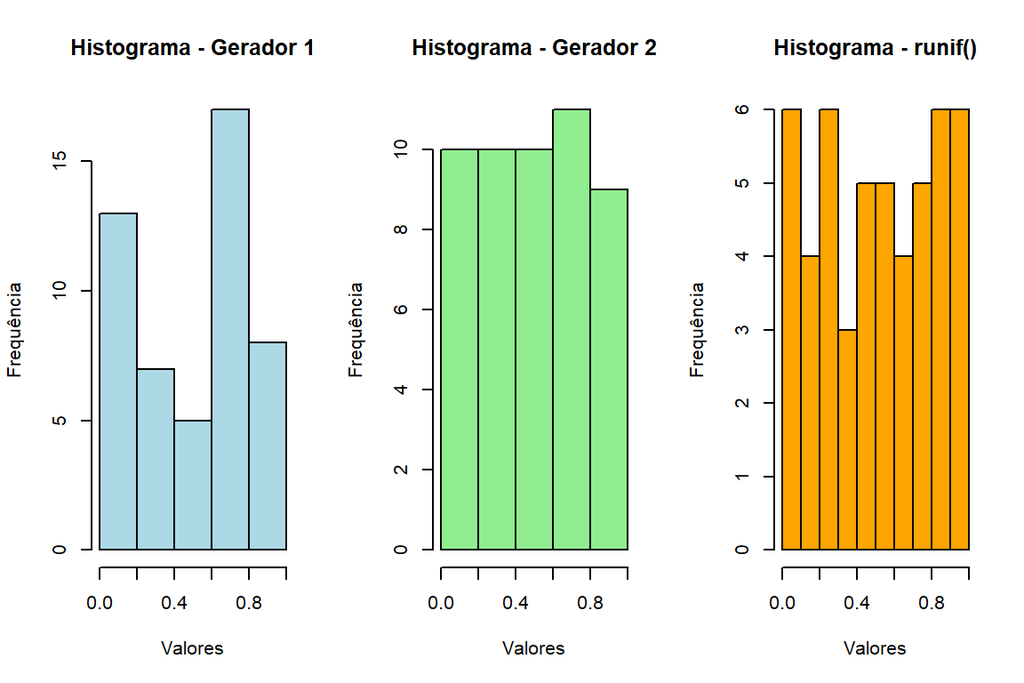

```r
par(mfrow = c(1, 3))
hist(vetor1, main = "Histograma - Gerador 1", col = "lightblue", xlab = "Valores", ylab = "Frequência")
hist(vetor2, main = "Histograma - Gerador 2", col = "lightgreen", xlab = "Valores", ylab = "Frequência")
hist(vetor3, main = "Histograma - runif()", col = "orange", xlab = "Valores", ylab = "Frequência")
```

## Grid 10x10 - Frequência de pares (x, y)

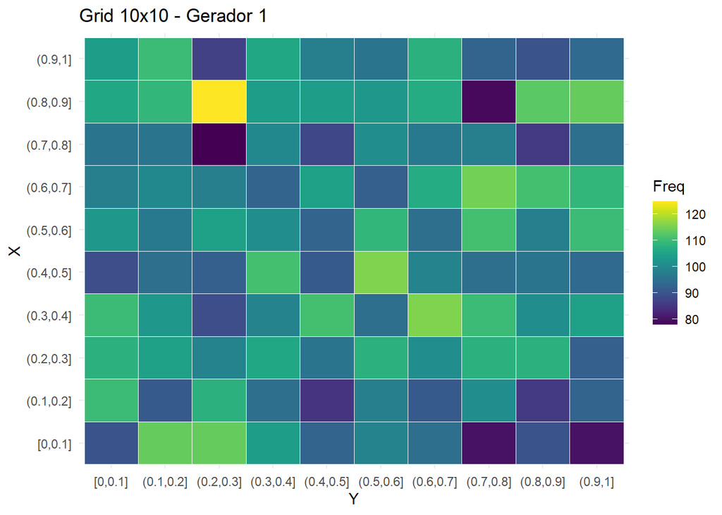

```r
library(ggplot2)
library(viridis)
n_pares <- 10000
val1 <- gerador_congruencial(2, 65539, 0, 2^31, 2 * n_pares)
val2 <- gerador_congruencial(2, 1664525, 1013904223, 2^32, 2 * n_pares)

x1 <- val1[seq(1, 2 * n_pares, by = 2)]
y1 <- val1[seq(2, 2 * n_pares, by = 2)]

x2 <- val2[seq(1, 2 * n_pares, by = 2)]
y2 <- val2[seq(2, 2 * n_pares, by = 2)]

breaks <- seq(0, 1, length.out = 11)

# Grid para Gerador 1
grid_x1 <- cut(x1, breaks, include.lowest = TRUE)
grid_y1 <- cut(y1, breaks, include.lowest = TRUE)
tabela1 <- table(grid_x1, grid_y1)
heatmap1 <- as.data.frame(tabela1)
colnames(heatmap1) <- c("X", "Y", "Freq")

# Grid para Gerador 2
grid_x2 <- cut(x2, breaks, include.lowest = TRUE)
grid_y2 <- cut(y2, breaks, include.lowest = TRUE)
tabela2 <- table(grid_x2, grid_y2)
heatmap2 <- as.data.frame(tabela2)
colnames(heatmap2) <- c("X", "Y", "Freq")

# Mapa de calor Gerador 1
ggplot(heatmap1, aes(x = Y, y = X, fill = Freq)) +
  geom_tile(color = "white") +
  scale_fill_viridis() +
  labs(title = "Grid 10x10 - Gerador 1", x = "Y", y = "X") +
  theme_minimal()
```

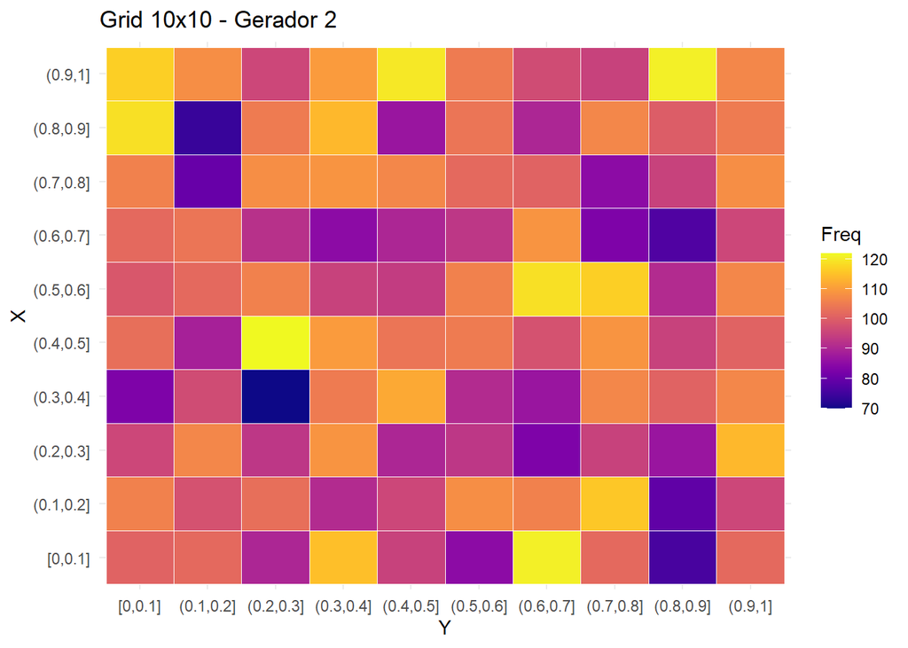

```r
# Mapa de calor Gerador 2
ggplot(heatmap2, aes(x = Y, y = X, fill = Freq)) +
  geom_tile(color = "white") +
  scale_fill_viridis(option = "C") +
  labs(title = "Grid 10x10 - Gerador 2", x = "Y", y = "X") +
  theme_minimal()
```

## Simulação com 1000 repetições do teste KS

```r
n <- 1000
p.g1 <- numeric(n)
p.g2 <- numeric(n)
p.g3 <- numeric(n)

for (i in 1:n) {
  g1 <- gen(x.0 = i, A =65539, B = 0, m = 2^31, inter = 50)
  g2 <- gen(x.0 = i, A =1664525, B = 1013904223, m = 2^32, inter = 50)
  g3 <- runif(50)

  p.g1[i] <- ks.test(g1, y = "punif")$p.value
  p.g2[i] <- ks.test(g2, y = "punif")$p.value
  p.g3[i] <- ks.test(g3, y = "punif")$p.value
}
```

## Função para Visualizar os p-valores

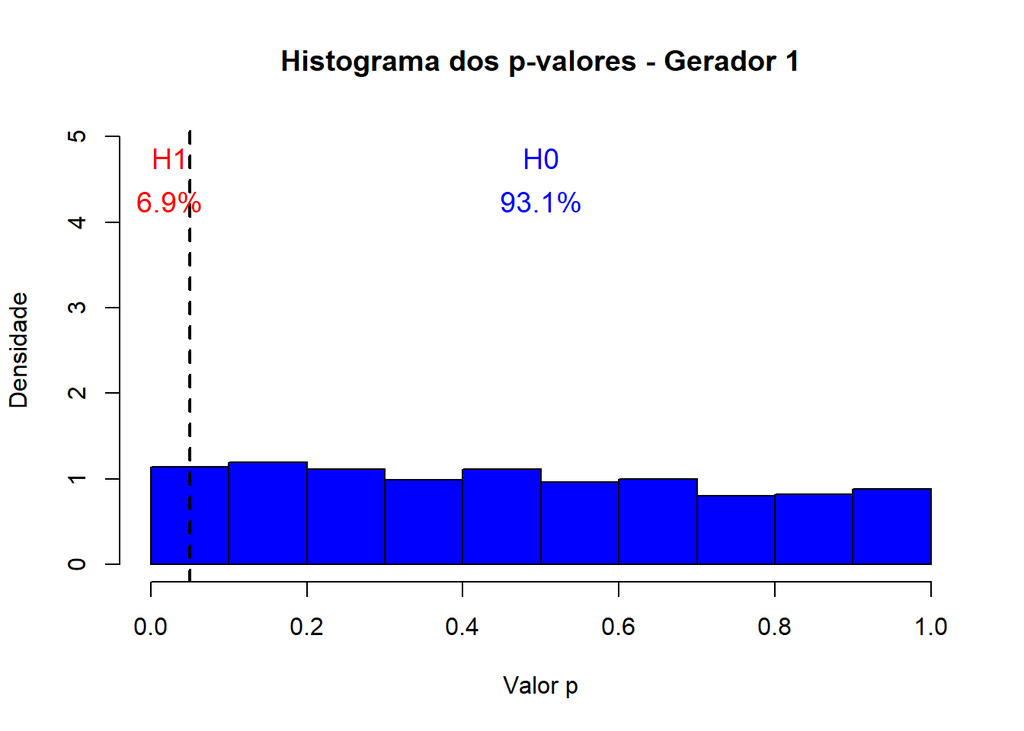

```r
plot_hist <- function(data, title, ylim = NULL) {
  h <- hist(data, plot = FALSE)
  colores <- ifelse(h$mids >= 0.05, "blue", "red")
  if(is.null(ylim)) {
    ylim <- c(0, max(h$density) * 1.2)
  }

  plot(h, freq = FALSE, col = colores, main = title,
       xlab = "Valor p", ylab = "Densidade", ylim = ylim, xlim = c(0, 1))
  abline(v = 0.05, lty = 2, lwd = 2)

  prop_h0 <- mean(data >= 0.05) * 100
  prop_h1 <- mean(data < 0.05) * 100

  text_y_pos <- ylim[2] * 0.95
  text_y_pos_prop <- ylim[2] * 0.85

  text(x = 0.5, y = text_y_pos, labels = "H0", col = "blue", cex = 1.2)
  text(x = 0.025, y = text_y_pos, labels = "H1", col = "red", cex = 1.2)

  text(x = 0.5, y = text_y_pos_prop, labels = paste0(round(prop_h0, 1), "%"), col = "blue", cex = 1.2)
  text(x = 0.025, y = text_y_pos_prop, labels = paste0(round(prop_h1, 1), "%"), col = "red", cex = 1.2)
}

plot_hist(p.g1, "Histograma dos p-valores - Gerador 1", ylim = c(0, 5))
```

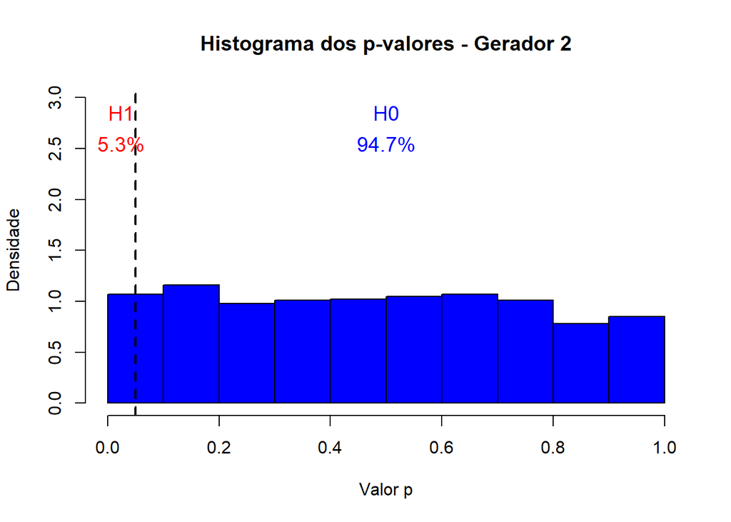

```r
plot_hist(p.g2, "Histograma dos p-valores - Gerador 2", ylim = c(0, 3))
```

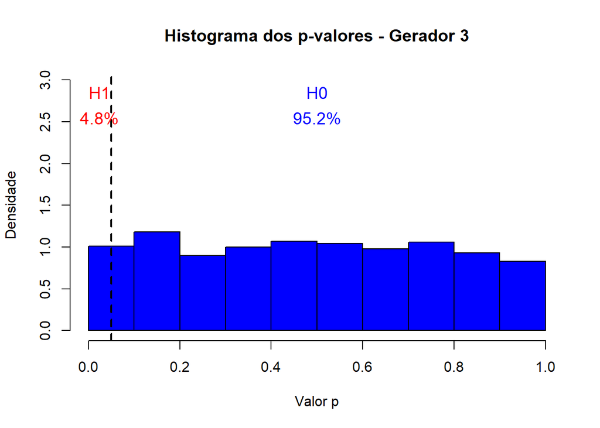

```r
plot_hist(p.g3, "Histograma dos p-valores - Gerador 3", ylim = c(0, 3))
```

## Estatísticas Resumidas dos p-valores

```r
cat("Estatísticas para o Gerador 1\n\n")
```

```
## Estatísticas para o Gerador 1
```

```r
summary(p.g1)
```

```
##      Min.   1st Qu.    Median      Mean   3rd Qu.      Max.
## 2.403e-05 2.210e-01 4.483e-01 4.671e-01 6.998e-01 9.998e-01
```

```r
cat("\n\nEstatísticas para o Gerador 2\n\n")
```

```
##
##
## Estatísticas para o Gerador 2
```

```r
summary(p.g2)
```

```
##      Min.   1st Qu.    Median      Mean   3rd Qu.      Max.
## 0.0005485 0.2335316 0.4752730 0.4787112 0.7080593 0.9997339
```

```r
cat("\n\nEstatísticas para o Gerador 3\n\n")
```

```
##
##
## Estatísticas para o Gerador 3
```

```r
summary(p.g3)
```

```
##      Min.   1st Qu.    Median      Mean   3rd Qu.      Max.
## 0.0009621 0.2303716 0.4836799 0.4862845 0.7300643 0.9994165
```

## Conclusão

Com base nos resultados obtidos ao longo da análise, podemos concluir que os três geradores avaliados — dois congruenciais lineares com diferentes parâmetros e o gerador nativo da linguagem R (runif) — produzem números aleatórios que seguem, de maneira geral, uma distribuição uniforme no intervalo [0, 1].

Através dos testes de Kolmogorov-Smirnov aplicados repetidamente, observamos que a maioria dos p-valores foi maior que 0.05, indicando que não rejeitamos a hipótese nula (H₀) de que os dados provêm de uma distribuição uniforme. Além disso, os mapas de calor 10x10 mostraram uma distribuição razoavelmente equilibrada dos pares (x, y) gerados, o que reforça a ideia de uniformidade bidimensional.

Dessa forma, os geradores estudados são adequados para simulações estatísticas que requerem variáveis uniformemente distribuídas — sendo o gerador nativo (runif) o mais robusto, como esperado, mas com os geradores congruenciais também apresentando resultados satisfatórios em termos de uniformidade.

## Divisão das Atividades por Participante

Para melhor organização e contribuição coletiva, o trabalho foi dividido em três partes, cada uma responsável por um gerador e suas respectivas análises.

Grupo 1 – Gerador Congruencial Linear 1 Integrantes:

Kailany

Josiene

Arthur

Jessica

Responsabilidades:

Implementação do gerador congruencial com parâmetros a = 65539, b = 0, m = 2^31.

Geração de 50 números e realização do teste de Kolmogorov-Smirnov.

Construção do histograma e análise dos p-valores.

Geração de pares (x, y) e criação do mapa de calor (grid 10x10).

Grupo 2 – Gerador Congruencial Linear 2 Integrantes:

Bruna

Bernardo

Lucca

Lucas Chaves

Responsabilidades:

Implementação do gerador congruencial com parâmetros a = 1664525, b = 1013904223, m = 2^32.

Geração de 50 números e aplicação do teste de Kolmogorov-Smirnov.

Construção do histograma e análise estatística dos p-valores.

Geração de pares (x, y) e mapa de calor (grid 10x10).

Grupo 3 – Gerador Nativo de R (runif) Integrantes:

Milena

Francielle

Caio

Gabriel

Responsabilidades:

Utilização do gerador runif para geração de 50 números aleatórios.

Realização de testes de Kolmogorov-Smirnov repetidos (n = 1000).

Construção do histograma dos p-valores e comparação com os demais geradores.

Interpretação dos resultados e suporte na redação da conclusão geral.